# NMF Final (Full time period))

William Zhang, Eva, Jerry, Meredith

2025-03-21

```r
# load the packages
library(NMF)
library(tidyverse)
library(grid)
library(gridExtra)
library(readxl)
library(circular)
library(lwgeom)
library(units)
```

# Procedure

1. Remove hourly observation with missing observation for any chemical
2. Remove background noise level using min values (except for chemicals with minimum value < 2*LOD and maximum value > 100*LOD)
3. Zero values are converted to a random value between 0 and 0.5*LOD
4. Normalize using min and max
5. Remove Ozone (wouldn’t affect # of obs.)

## Reading the data

```r
hourly_data <- readRDS("../DataProcessing/Trailer_hourly_merge_20240905.rds")
```

```r
# PROCEDURE STEP 1:
hourly_data <- hourly_data %>% rename('co2' = 'co2_ppm')

vocs <- c("ethane", "ethene", "propane", "propene",
                                        "1_3-butadiene", "i-butane", "n-butane",
                                        "acetylene", "cyclopentane", "i-pentane",
                                        "n-pentane", "n-hexane", "isoprene", "n-heptane",
                                        "benzene", "n-octane", "toluene", "ethyl-benzene",
                                        "m&p-xylene", "o-xylene")


non_vocs <- c('ch4', 'co2', 'co', 'h2s', 'so2', 'nox', 'o3')

# remove row with missing obs for any chemical
hourly_nona <- hourly_data %>%
  select(any_of(c('day', 'time_utc', vocs, non_vocs, 'wdr_deg', 'wsp_ms'))) %>%
  na.omit()

# retrieving the vocs, removing everything else except the vocs
hourly_vocs <- hourly_nona %>% select(any_of(vocs))

# retrieving the non-vocs: co2_ppm, nox, ch4, h2s, so2, o3
# double check this
hourly_non_vocs <- hourly_nona %>% select(any_of(non_vocs))

hourly_full_nona <- cbind(hourly_non_vocs, hourly_vocs)

# retrive a vector of yearmonth
hourly_dates <- hourly_nona %>%
  mutate(yearmonth = substring(day, 0, 7)) %>%
  pull(yearmonth)
```

## Data visualisation

- Boxplots of the hourly concentrations non-voc

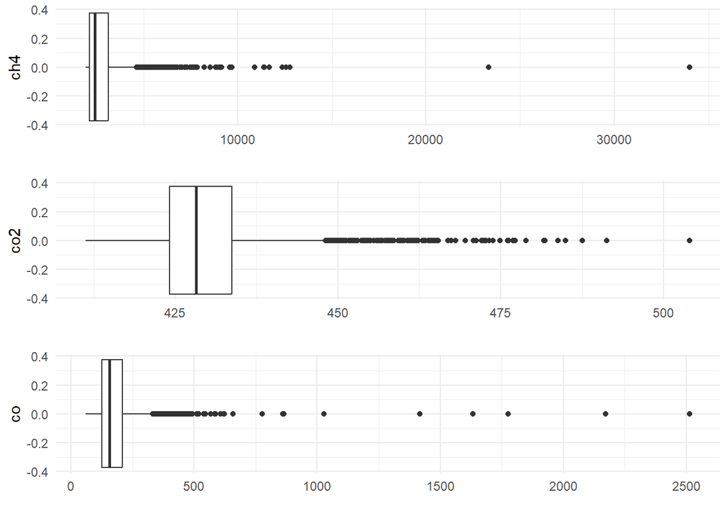

- Boxplots sulfur compounds, NOx, ozone

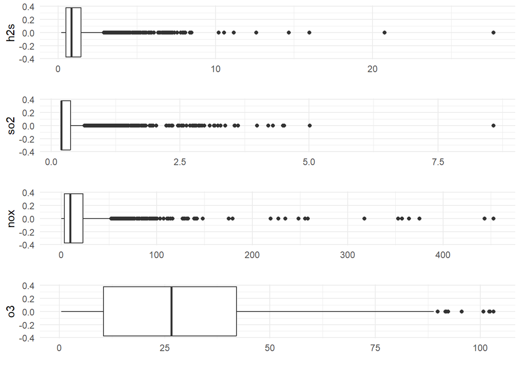

- Boxplots VOCs

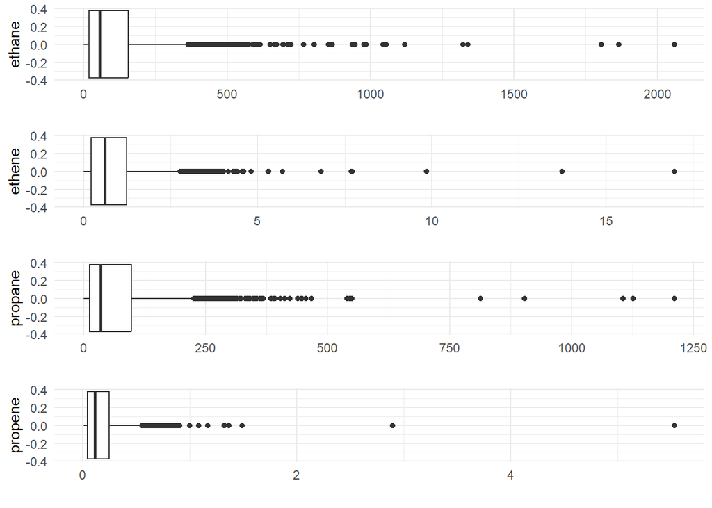

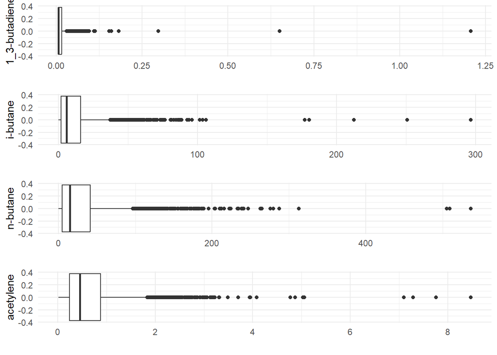

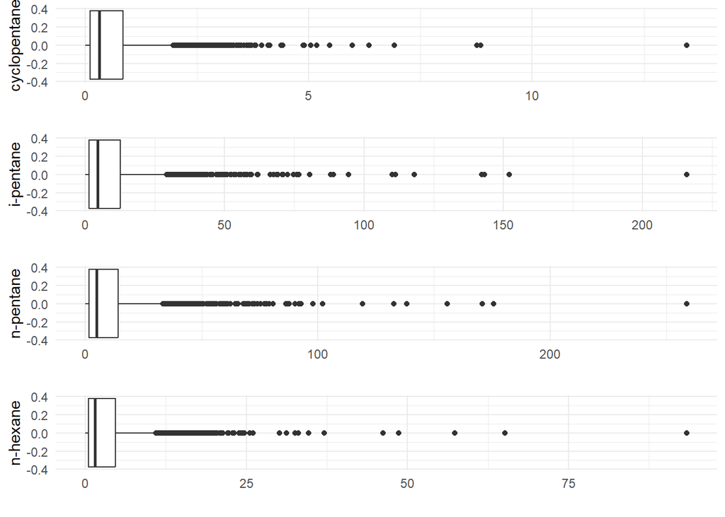

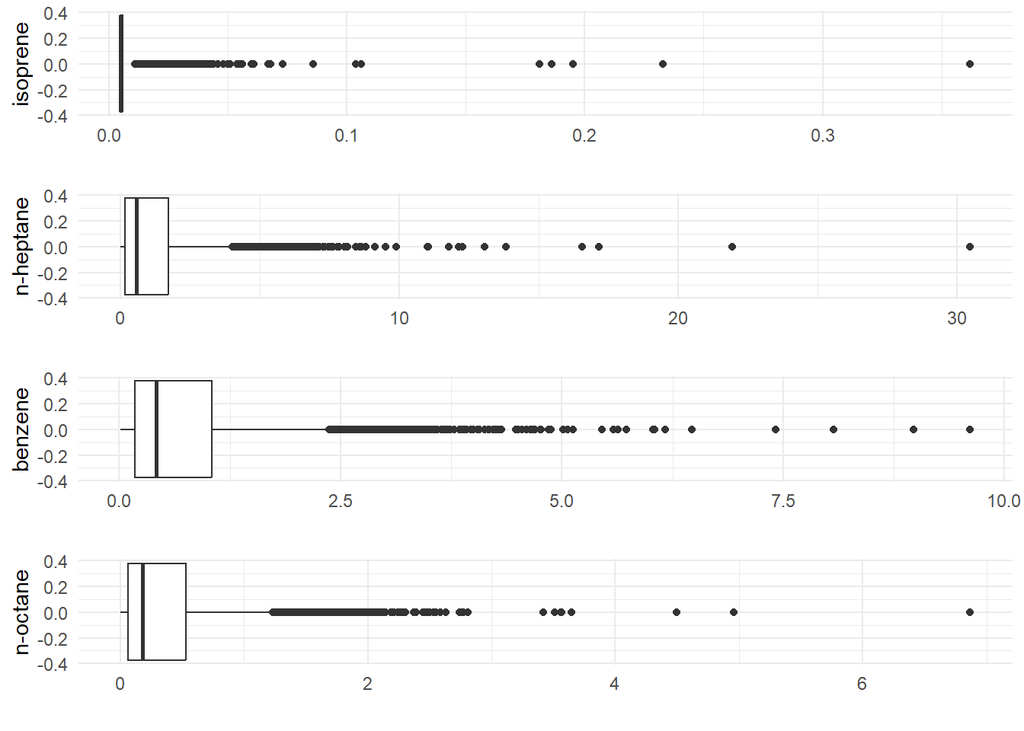

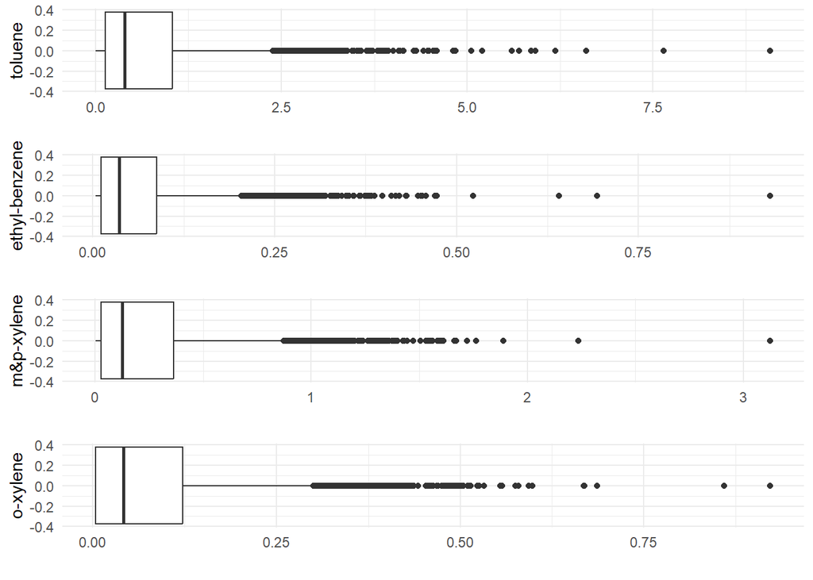

### Data pre-processing

#### Step 1: limits of detection

- STEP 1: Limits of detection

```r
# Define LOD for each chemical
LOD_non_voc <- c('ch4' = 0.9,
             'co2' = 0.0433,
             'co' = 40,
             'h2s' = 0.4,
             'so2' = 0.4,
             'nox' = 0.05,
             'o3' = 1)

# LOD_voc_monthly <- read_csv('../data/LNM_VOC_LOD_Rounded.csv') %>% select(-1)
#
# # extract the yearmonth from date variables
# LOD_voc_monthly <- LOD_voc_monthly %>%
#   mutate(yearmonth = strftime(as.POSIXct(start_date, format = '%Y-%m-%d %H:%M:%S',
#                                             tz = 'UTC'), '%Y-%m'))
#
# LOD_voc_monthly <- LOD_voc_monthly %>%
#   select(-c(start_date, end_date)) %>%
#   select(!any_of(ends_with('half_ldl')))
#
# colnames(LOD_voc_monthly) <- str_replace_all(names(LOD_voc_monthly), '_ldl', '')

LOD_voc_avg <- read_xlsx('../data/LNM_VOC_Uncertainties.xlsx', skip = 1)
LOD_voc_avg <- LOD_voc_avg %>%
  select(1, 4) %>%
  rename('LOD' = 2, 'chemical' = 1) %>%
  head(20)
```

#### Step 2: Background correction

- STEP 2: Background correction

```
##           ch4           co2            co           h2s           so2
##      1928.000       411.300        59.910         0.200         0.200
##           nox            o3        ethane        ethene       propane
##         0.025         0.500         0.916         0.011         0.224
##       propene 1_3-butadiene      i-butane      n-butane     acetylene
##         0.009         0.007         0.035         0.090         0.019
##  cyclopentane     i-pentane     n-pentane      n-hexane      isoprene
##         0.005         0.038         0.042         0.021         0.005
##     n-heptane       benzene      n-octane       toluene ethyl-benzene
##         0.004         0.017         0.004         0.004         0.004
##    m&p-xylene      o-xylene
##         0.004         0.004
```

- Summary statistics of backgrounds and extremes

```r
get_info <- function(column) {
  N <- length(column)
  background <- quantile(column, 0)
  quantile1 <- quantile(column, 0.01)
  quantile99 <- quantile(column, 0.99)
  n_background <- sum(column == background)
  max <- max(column)
  return(c(N, quantile1, quantile99, max, background, n_background))
}

info_table <- hourly_full_nona %>%
  reframe(across(everything(), ~ get_info(.x)))

info_table <- info_table %>%
  mutate(rownames = c('N', '1st percentile', '99th percentile', 'Max',
                      'Background', '# Background')) %>%
  pivot_longer(-rownames) %>%
  pivot_wider(names_from = rownames, values_from = value)

knitr::kable(info_table)
```

| name | N | 1st percentile | 99th percentile | Max | Background | # Background |
| --- | --- | --- | --- | --- | --- | --- |
| ch4 | 4788 | 1962.98700 | 6286.12400 | 34010.900 | 1928.000 | 1 |
| co2 | 4788 | 416.47870 | 460.62260 | 503.990 | 411.300 | 1 |
| co | 4788 | 84.23050 | 442.08860 | 2513.440 | 59.910 | 1 |
| h2s | 4788 | 0.20000 | 5.20986 | 27.700 | 0.200 | 829 |
| so2 | 4788 | 0.20000 | 1.78686 | 8.578 | 0.200 | 3266 |
| nox | 4788 | 0.22974 | 89.72371 | 452.959 | 0.025 | 2 |
| o3 | 4788 | 0.50000 | 76.02600 | 103.100 | 0.500 | 259 |
| ethane | 4788 | 1.84422 | 526.44700 | 2060.000 | 0.916 | 1 |
| ethene | 4788 | 0.01100 | 3.50826 | 16.970 | 0.011 | 163 |
| propane | 4788 | 0.84674 | 300.79000 | 1211.000 | 0.224 | 1 |
| propene | 4788 | 0.00900 | 0.69739 | 5.528 | 0.009 | 411 |
| 1_3-butadiene | 4788 | 0.00700 | 0.05900 | 1.207 | 0.007 | 3357 |
| i-butane | 4788 | 0.15148 | 60.89400 | 296.600 | 0.035 | 1 |
| n-butane | 4788 | 0.37248 | 166.52100 | 536.900 | 0.090 | 1 |
| acetylene | 4788 | 0.04900 | 2.61304 | 8.471 | 0.019 | 2 |
| cyclopentane | 4788 | 0.00500 | 3.06899 | 13.460 | 0.005 | 96 |
| i-pentane | 4788 | 0.10987 | 49.60210 | 215.900 | 0.038 | 1 |
| n-pentane | 4788 | 0.10487 | 55.95980 | 258.800 | 0.042 | 1 |
| n-hexane | 4788 | 0.04300 | 18.17780 | 93.360 | 0.021 | 2 |
| isoprene | 4788 | 0.00500 | 0.03313 | 0.362 | 0.005 | 2816 |
| n-heptane | 4788 | 0.01500 | 6.57669 | 30.470 | 0.004 | 5 |
| benzene | 4788 | 0.02800 | 3.78693 | 9.610 | 0.017 | 3 |
| n-octane | 4788 | 0.00400 | 2.00839 | 6.867 | 0.004 | 100 |
| toluene | 4788 | 0.01300 | 3.52165 | 9.077 | 0.004 | 11 |
| ethyl-benzene | 4788 | 0.00400 | 0.31613 | 0.931 | 0.004 | 918 |
| m&p-xylene | 4788 | 0.00400 | 1.29156 | 3.123 | 0.004 | 851 |
| o-xylene | 4788 | 0.00400 | 0.45700 | 0.922 | 0.004 | 1330 |

- STEP 2 processing continued: background correction
- adjustments that were made according to paper: Gunnar’s paper section 2.2 and Guha 3.3
- Check whether chemical has background noise level that needs to be removed
- NO ADJUSTMENT if minimum value < 2xLOD and maximum value > 100xLOD

```r
adjusting_neg_bg_from_lod <- function(chemical, LOD, background, hourly_data){
    # get min and max
    min_value <- min(hourly_data[chemical], na.rm = TRUE)
    max_value <- max(hourly_data[chemical], na.rm = TRUE)
    # if min less than double LOD or max > 100 times LOD
    # adjust to -100 (for entire column???)
    if (min_value < 2 * LOD & max_value > 100 * LOD ){
      return (0)
    }
  return (background)
}
```

- Check if background is negligible for non voc
- merge background and LOD

```r
background_lod_non_voc <- tibble(chemical = non_vocs,
                                 LOD = LOD_non_voc,
                                 background = unname(background_levels[non_vocs]))
adjusted_background_non_voc <- background_lod_non_voc %>%
  rowwise() %>%
  mutate(min = min(hourly_full_nona[chemical], na.rm = TRUE),
         LODx2 = 2 * LOD,
         criterion1 = min(hourly_full_nona[chemical], na.rm = TRUE) < 2 * LOD,
         max = max(hourly_full_nona[chemical], na.rm = TRUE),
         LODx100 = 100 * LOD,
         criterion2 = max(hourly_full_nona[chemical], na.rm = TRUE) > 100 * LOD,
         adjusted_background = adjusting_neg_bg_from_lod(chemical, LOD, background,
                                                         hourly_full_nona))
```

- Check if background is negligible for voc
- merge background and LOD

```r
background_lod_voc <- LOD_voc_avg %>%
  left_join(tibble(chemical = setdiff(names(background_levels), non_vocs),
                   background = background_levels[setdiff(names(background_levels),
                                                          non_vocs)]))
adjusted_background_voc <- background_lod_voc %>%
  rowwise() %>%
  mutate(min = min(hourly_full_nona[chemical], na.rm = TRUE),
         LODx2 = 2 * LOD,
         criterion1 = min(hourly_full_nona[chemical], na.rm = TRUE) < 2 * LOD,
         max = max(hourly_full_nona[chemical], na.rm = TRUE),
         LODx100 = 100 * LOD,
         criterion2 = max(hourly_full_nona[chemical], na.rm = TRUE) > 100 * LOD,
         adjusted_background = adjusting_neg_bg_from_lod(chemical, LOD, background,
                                                         hourly_full_nona))
```

- create dataset with background removed

```r
# So now we have the adjusted background concentrations
hourly_nona_bgrm <- hourly_full_nona %>%
  mutate(across(adjusted_background_non_voc$chemical,
                ~  .x - adjusted_background_non_voc$adjusted_background[
                    adjusted_background_non_voc$chemical == cur_column()]))
hourly_nona_bgrm <- hourly_nona_bgrm %>%
  mutate(across(adjusted_background_voc$chemical,
                ~  .x - adjusted_background_voc$adjusted_background[
                    adjusted_background_voc$chemical == cur_column()]))
```

- check number of 0 values per compound

```r
# look at zero values
colSums(hourly_nona_bgrm == 0)
```

```
##           ch4           co2            co           h2s           so2
##             1             1             1           829          3266
##           nox            o3        ethane        ethene       propane
##             0             0             1             0             1
##       propene 1_3-butadiene      i-butane      n-butane     acetylene
##             0          3357             1             1             0
##  cyclopentane     i-pentane     n-pentane      n-hexane      isoprene
##             0             1             1             2          2816
##     n-heptane       benzene      n-octane       toluene ethyl-benzene
##             0             0             0             0             0
##    m&p-xylene      o-xylene
##             0             0
```

#### Step 3: Replace zero with random value between 0 and 0.5*LOD

- STEP 3: replace zero values with random values between 0 and 0.5xLOD

```r
set.seed(123)
replace_zero_with_random <- function(column, name, LOD_df){
  LOD <- LOD_df$LOD[LOD_df$chemical == name]
  column <- if_else(column == 0, round(runif(length(column), 0, 0.5 * LOD), 3), column)
  return (column)
}

hourly_nona_bgrm_zerorepl <- hourly_nona_bgrm %>%
  mutate(across(adjusted_background_non_voc$chemical,
                ~ replace_zero_with_random(.x, cur_column(), adjusted_background_non_voc)))

hourly_nona_bgrm_zerorepl <- hourly_nona_bgrm_zerorepl %>%
  mutate(across(adjusted_background_voc$chemical,
                ~ replace_zero_with_random(.x, cur_column(), adjusted_background_voc)))
```

#### Step 4: Normalize

- STEP 4: Normalize the measurements

```r
#normalizing function
normalize_column <- function(column){
  background <- quantile(column, 0)
  max <- quantile(column, 1) # this could be adjusted
  return ((column - background)/(max - background))
}
```

```r
# normalize all
hourly_nona_bgrm_zerorepl_norm <- as_tibble(sapply(as.list(hourly_nona_bgrm_zerorepl),
                                                   normalize_column))
#normalize the NON_VOC
summary(hourly_nona_bgrm_zerorepl_norm)
```

```
##       ch4               co2               co               h2s
##  Min.   :0.00000   Min.   :0.0000   Min.   :0.00000   Min.   :0.00000
##  1st Qu.:0.00579   1st Qu.:0.1384   1st Qu.:0.02592   1st Qu.:0.01022
##  Median :0.01460   Median :0.1823   Median :0.03884   Median :0.02335
##  Mean   :0.02683   Mean   :0.2000   Mean   :0.04761   Mean   :0.03501
##  3rd Qu.:0.03720   3rd Qu.:0.2418   3rd Qu.:0.05970   3rd Qu.:0.04525
##  Max.   :1.00000   Max.   :1.0000   Max.   :1.00000   Max.   :1.00000
##       so2                nox                 o3              ethane
##  Min.   :0.000000   Min.   :0.000000   Min.   :0.00000   Min.   :0.000000
##  1st Qu.:0.007878   1st Qu.:0.006534   1st Qu.:0.09747   1st Qu.:0.008385
##  Median :0.015994   Median :0.020262   Median :0.25487   Median :0.026671
##  Mean   :0.026287   Mean   :0.036440   Mean   :0.26676   Mean   :0.050992
##  3rd Qu.:0.023633   3rd Qu.:0.049978   3rd Qu.:0.40546   3rd Qu.:0.075375
##  Max.   :1.000000   Max.   :1.000000   Max.   :1.00000   Max.   :1.000000
##      ethene           propane            propene         1_3-butadiene
##  Min.   :0.00000   Min.   :0.000000   Min.   :0.000000   Min.   :0.000000
##  1st Qu.:0.01268   1st Qu.:0.009283   1st Qu.:0.005979   1st Qu.:0.002500
##  Median :0.03547   Median :0.028409   Median :0.018482   Median :0.004167
##  Mean   :0.05042   Mean   :0.053803   Mean   :0.028772   Mean   :0.007371
##  3rd Qu.:0.07266   3rd Qu.:0.080130   3rd Qu.:0.042761   3rd Qu.:0.007500
##  Max.   :1.00000   Max.   :1.000000   Max.   :1.000000   Max.   :1.000000
##     i-butane          n-butane          acetylene        cyclopentane
##  Min.   :0.00000   Min.   :0.000000   Min.   :0.00000   Min.   :0.000000
##  1st Qu.:0.00614   1st Qu.:0.008777   1st Qu.:0.02674   1st Qu.:0.007432
##  Median :0.01925   Median :0.027522   Median :0.05135   Median :0.022668
##  Mean   :0.03837   Mean   :0.054900   Mean   :0.07436   Mean   :0.043730
##  3rd Qu.:0.05369   3rd Qu.:0.077042   3rd Qu.:0.10211   3rd Qu.:0.062653
##  Max.   :1.00000   Max.   :1.000000   Max.   :1.00000   Max.   :1.000000
##    i-pentane          n-pentane           n-hexane           isoprene
##  Min.   :0.000000   Min.   :0.000000   Min.   :0.000000   Min.   :0.000000
##  1st Qu.:0.006303   1st Qu.:0.005681   1st Qu.:0.004703   1st Qu.:0.002801
##  Median :0.019941   Median :0.018371   Median :0.016039   Median :0.005602
##  Mean   :0.041094   Mean   :0.038859   Mean   :0.034979   Mean   :0.010315
##  3rd Qu.:0.057857   3rd Qu.:0.054837   3rd Qu.:0.049544   3rd Qu.:0.011204
##  Max.   :1.000000   Max.   :1.000000   Max.   :1.000000   Max.   :1.000000
##    n-heptane           benzene           n-octane           toluene
##  Min.   :0.000000   Min.   :0.00000   Min.   :0.000000   Min.   :0.00000
##  1st Qu.:0.005473   1st Qu.:0.01637   1st Qu.:0.008269   1st Qu.:0.01389
##  Median :0.018348   Median :0.04222   Median :0.026009   Median :0.04276
##  Mean   :0.039328   Mean   :0.07655   Mean   :0.054341   Mean   :0.07825
##  3rd Qu.:0.055866   3rd Qu.:0.10779   3rd Qu.:0.076497   3rd Qu.:0.11333
##  Max.   :1.000000   Max.   :1.00000   Max.   :1.000000   Max.   :1.00000
##  ethyl-benzene        m&p-xylene          o-xylene
##  Min.   :0.000000   Min.   :0.000000   Min.   :0.00000
##  1st Qu.:0.007551   1st Qu.:0.007374   1st Qu.:0.00000
##  Median :0.034520   Median :0.039115   Median :0.04139
##  Mean   :0.062378   Mean   :0.077508   Mean   :0.08650
##  3rd Qu.:0.090615   3rd Qu.:0.115742   3rd Qu.:0.12881
##  Max.   :1.000000   Max.   :1.000000   Max.   :1.00000
```

- FINAL step: create matrix of processed and normalized concentrations for NMF

```r
normalized_matrix <- as.matrix(hourly_nona_bgrm_zerorepl_norm)
#important: using the normalized VOCs for this file
```

# NMF section

## Preprocess

### Global variables

```r
components <- 4:10
```

### Remove Ozone

```r
normalized_matrix_less_o3 <- normalized_matrix[ ,setdiff(colnames(normalized_matrix), "o3")]
```

### Compute error matrix

```r
# compute uncertainty matrix (inverse of weight?)
# Based on the Guha paper

uncertainty_matrix <- matrix(0, nrow = nrow(normalized_matrix_less_o3),
                        ncol = ncol(normalized_matrix_less_o3))
LOD_merged <- tibble(chemical = c(adjusted_background_non_voc$chemical,
                                  adjusted_background_voc$chemical),
                     LOD = c(adjusted_background_non_voc$LOD,
                             adjusted_background_voc$LOD))

LOD_merged <- tibble(chemical = names(hourly_nona_bgrm_zerorepl_norm)) %>%
  left_join(LOD_merged) %>%
  filter(chemical %in% colnames(normalized_matrix_less_o3))
# creating uncertainty Matrix
for (i in 1:dim(uncertainty_matrix)[1]) {
  for (j in 1:dim(uncertainty_matrix)[2]) {
    chemical <- colnames(normalized_matrix_less_o3)[j]
    xij <- normalized_matrix_less_o3[i, j]
    LOD <- LOD_merged$LOD[LOD_merged$chemical == chemical]
    # Get LOD value for this row
    # Based on Guha Eq6, Eq5a, EQ5c
    # if (j == 1) {
    #   # based on equation 6, we sqrt ch4 (at column = 1) and times by 1
    #   uncertainty_matrix[i, j] <- sqrt(xij)
    # } else if (j == 2) {
    #   # 0.25 for co2
    #   uncertainty_matrix[i, j] <- 0.25 * sqrt(xij)
    # } else if (j == 3) {
    #   # 0.5 for CO
    #   uncertainty_matrix[i, j] <- 0.5 * sqrt(xij)
    # } else if (xij <= LOD) {
    #   uncertainty_matrix[i, j] <- 2 * LOD # equation 5a) in reference paper
    # } else {
    #   uncertainty_matrix[i, j] <- sqrt(((0.1 * xij)**2 + LOD**2))  #equation 5c) in reference paper
    # }

    # Based on Guha Eq5a, EQ5c
    if (xij <= LOD) {
      uncertainty_matrix[i, j] <- 2 * LOD # equation 5a) in reference paper
    } else {
      uncertainty_matrix[i, j] <- sqrt(((0.1 * xij)**2 + LOD**2))  #equation 5c) in reference paper
    }
  }
}
```

```r
# Convert zero uncertainties to the next smallest uncertainty of the corresponding compound
uncertainty_matrix[uncertainty_matrix==0]<-apply(uncertainty_matrix, 2, function(x) sort(x)[2])
# THIS NEEDS TO BE CHECKED IF WE WANT TO TAKE RECIPROCAL FOR EACH ELEMENT
# CURRENT RESULTS IS WHEN WEIGHT = UNCERTAINTY
# NOT POSSIBLE TO DO SIMPLY TAKE RECIPROCAL SINCE THERE'RE 0 UNCERTAINTIES
weight_matrix <- 1/uncertainty_matrix

summary(weight_matrix)
```

```
##        V1               V2               V3               V4
##  Min.   :0.5556   Min.   : 9.177   Min.   :0.0125   Min.   :1.250
##  1st Qu.:0.5556   1st Qu.:20.140   1st Qu.:0.0125   1st Qu.:1.250
##  Median :0.5556   Median :21.279   Median :0.0125   Median :1.250
##  Mean   :0.5557   Mean   :20.803   Mean   :0.0125   Mean   :1.251
##  3rd Qu.:0.5556   3rd Qu.:21.990   3rd Qu.:0.0125   3rd Qu.:1.250
##  Max.   :1.1043   Max.   :22.970   Max.   :0.0125   Max.   :2.484
##        V5              V6               V7               V8
##  Min.   :1.250   Min.   : 8.944   Min.   : 9.678   Min.   : 9.746
##  1st Qu.:1.250   1st Qu.:10.000   1st Qu.:19.231   1st Qu.:21.739
##  Median :1.250   Median :10.000   Median :23.293   Median :39.121
##  Mean   :1.253   Mean   :12.384   Mean   :27.649   Mean   :33.580
##  3rd Qu.:1.250   3rd Qu.:10.000   3rd Qu.:36.985   3rd Qu.:42.365
##  Max.   :2.488   Max.   :19.900   Max.   :38.271   Max.   :43.261
##        V9              V10              V11              V12
##  Min.   : 9.859   Min.   : 9.842   Min.   : 9.903   Min.   : 9.903
##  1st Qu.:29.412   1st Qu.:27.778   1st Qu.:35.714   1st Qu.:35.714
##  Median :46.347   Median :44.285   Median :35.714   Median :54.768
##  Mean   :43.621   Mean   :40.618   Mean   :40.512   Mean   :52.185
##  3rd Qu.:56.564   3rd Qu.:54.112   3rd Qu.:35.714   3rd Qu.:68.687
##  Max.   :58.528   Max.   :55.276   Max.   :71.066   Max.   :71.074
##       V13              V14              V15              V16
##  Min.   : 9.917   Min.   : 9.187   Min.   : 9.917   Min.   : 9.95
##  1st Qu.:38.462   1st Qu.:11.628   1st Qu.:38.462   1st Qu.:50.00
##  Median :59.325   Median :21.253   Median :60.265   Median :75.75
##  Mean   :56.622   Mean   :17.687   Mean   :56.700   Mean   :73.01
##  3rd Qu.:73.720   3rd Qu.:22.820   3rd Qu.:73.711   3rd Qu.:95.52
##  Max.   :76.540   Max.   :23.140   Max.   :76.541   Max.   :99.50
##       V17             V18              V19             V20
##  Min.   : 9.95   Min.   :  9.96   Min.   : 9.94   Min.   :  9.968
##  1st Qu.:50.00   1st Qu.: 55.56   1st Qu.:45.45   1st Qu.: 62.500
##  Median :74.81   Median : 80.74   Median :45.45   Median : 89.534
##  Mean   :72.66   Mean   : 80.01   Mean   :59.24   Mean   : 89.780
##  3rd Qu.:95.23   3rd Qu.:105.43   3rd Qu.:89.08   3rd Qu.:118.592
##  Max.   :99.50   Max.   :110.56   Max.   :90.44   Max.   :124.378
##       V21              V22               V23               V24
##  Min.   :  9.96   Min.   :  9.968   Min.   :  9.968   Min.   :  9.968
##  1st Qu.: 55.56   1st Qu.: 62.500   1st Qu.: 62.500   1st Qu.: 62.500
##  Median : 85.48   Median : 91.169   Median : 88.561   Median : 81.631
##  Mean   : 80.33   Mean   : 89.312   Mean   : 86.618   Mean   : 85.245
##  3rd Qu.:105.73   3rd Qu.:119.159   3rd Qu.:118.236   3rd Qu.:114.204
##  Max.   :110.55   Max.   :124.377   Max.   :124.373   Max.   :124.279
##       V25               V26
##  Min.   :  9.968   Min.   :  9.968
##  1st Qu.: 62.500   1st Qu.: 62.500
##  Median : 69.955   Median : 62.500
##  Mean   : 80.748   Mean   : 73.996
##  3rd Qu.:111.760   3rd Qu.: 98.097
##  Max.   :124.377   Max.   :124.265
```

### Helper functions for plots

```r
get_fingerprint_plot <- function(H, factor_names = c('Factor 1', 'Factor 2',
                                                     'Factor 3', 'Factor 4',
                                                     'Factor 5')){
  custom_colors <- setNames(color_pal,
                            factor_names)

  # Convert to proportions
  contrib_prop <- apply(H[,1:(length(H)-1)], MARGIN = 2,
                        FUN = function(x) {x/sum(x)})

  contrib_prop <- contrib_prop %>%
    as_tibble() %>%
    mutate(Component = factor_names) %>%
    mutate(Component = factor(Component, levels = factor_names)) %>%
    pivot_longer(cols = -Component,
                 names_to = "Chemical",
                 values_to = "Contribution_prop") %>%
    mutate(Chemical = factor(Chemical, levels = desired_order))

  return(contrib_prop %>%
    ggplot(aes(fill = Component, y = Contribution_prop, x = Chemical)) +
    geom_bar(position = "fill", stat = "identity") +
    scale_fill_manual(values = custom_colors) +
    theme(axis.text.x = element_text(angle = 45, hjust = 1)) +
    labs(x = "Chemical", y = "Contribution Proportion") +
    theme(
      panel.grid.major = element_blank(),
      panel.grid.minor = element_blank(),
      panel.background = element_blank()
    ))
}
```

```r
hourly_wind_nona <- hourly_nona %>%
  select(wdr_deg, wsp_ms)

get_wind_plot_data <- function(W, factor_names = c('Factor 1', 'Factor 2',
                                                     'Factor 3', 'Factor 4',
                                                     'Factor 5')){
  data_to_plot <- tibble(
    component1 = W[, 1],
    component2 = W[, 2],
    component3 = W[, 3],
    component4 = W[, 4],
    component5 = W[, 5],
    wd = round(hourly_wind_nona$wdr_deg, -1)
  )

  data_long <- data_to_plot %>%
  pivot_longer(cols = starts_with("component"), names_to = "Factor", values_to = "Expression")

  data_long <- data_long %>%
    mutate(wd = factor(wd, levels = sort(unique(wd))))

  data_long
}

get_wind_plots <- function(W, y_axis_upper = rep(10, 5),
                               factor_names = c('Factor 1', 'Factor 2',
                                                     'Factor 3', 'Factor 4',
                                                     'Factor 5')){
  data_long <- get_wind_plot_data(W, factor_names)

  # Select every second wind direction for labeling
  every_second_label <- levels(data_long$wd)[seq(1, length(levels(data_long$wd)), by = 2)]

  factor_labels <- setNames(paste(c('Factor 1', 'Factor 2','Factor 3', 'Factor 4',
                                    'Factor 5'), ' - ', factor_names), paste0('component', 1:5))

  y_axis_limits <- list(
    "component1" = c(0, y_axis_upper[1]),
    "component2" = c(0, y_axis_upper[2]),
    "component3" = c(0, y_axis_upper[3]),
    "component4" = c(0, y_axis_upper[4]),
    "component5" = c(0, y_axis_upper[5])
  )


  plots <- lapply(1:5, function(i) {
    factor_name <- paste0("component", i)

    ggplot(data_long %>% filter(Factor == factor_name),
           aes(x = wd, y = Expression, fill = as.factor(wd))) +
      geom_boxplot(outliers=F, size=0.3) +
      scale_fill_manual(values = rep(color_pal[i], length(unique(data_long$wd)))) +
      scale_x_discrete(breaks = every_second_label) +
      coord_cartesian(ylim = y_axis_limits[[factor_name]]) +
      scale_y_continuous(
        limits = c(0, NA),
        breaks = seq(0, y_axis_limits[[factor_name]][2], length.out = 5) ,
        expand=expansion(mult=c(0))
      ) +
      labs(title = factor_labels[factor_name],
           x = "Wind Direction (°)",
           y = "Factor Expression") +
      theme_minimal() +
      theme(
        legend.position = "none",
        plot.title = element_text(size = 6),  # Smaller title text
        axis.title = element_text(size = 6),  # Smaller axis labels
        axis.text = element_text(size = 6),  # Smaller x and y tick labels
        axis.text.x = element_text(angle = 45, hjust = 1)
      )
  })

  return(plots)
}
```

## LS-NMF + Random seed

```r
# for each rank, run 30 models and find best one
# start_time_lsnmf_rand <- Sys.time()
#
# lsnmf_random_less_o3 <- nmf(
#   normalized_matrix_less_o3,
#   components,
#   method = "ls-nmf",
#   weight = weight_matrix,
#   30,
#   seed = 123456
# )
#
# end_time_lsnmf_rand <- Sys.time()
# end_time_lsnmf_rand-start_time_lsnmf_rand
# # 18.8 minutes to run the above

# saveRDS(lsnmf_random_less_o3,
#         'lsnmf_random_less_o3.rds')
lsnmf_random_less_o3 <- readRDS('lsnmf_random_less_o3.rds')
```

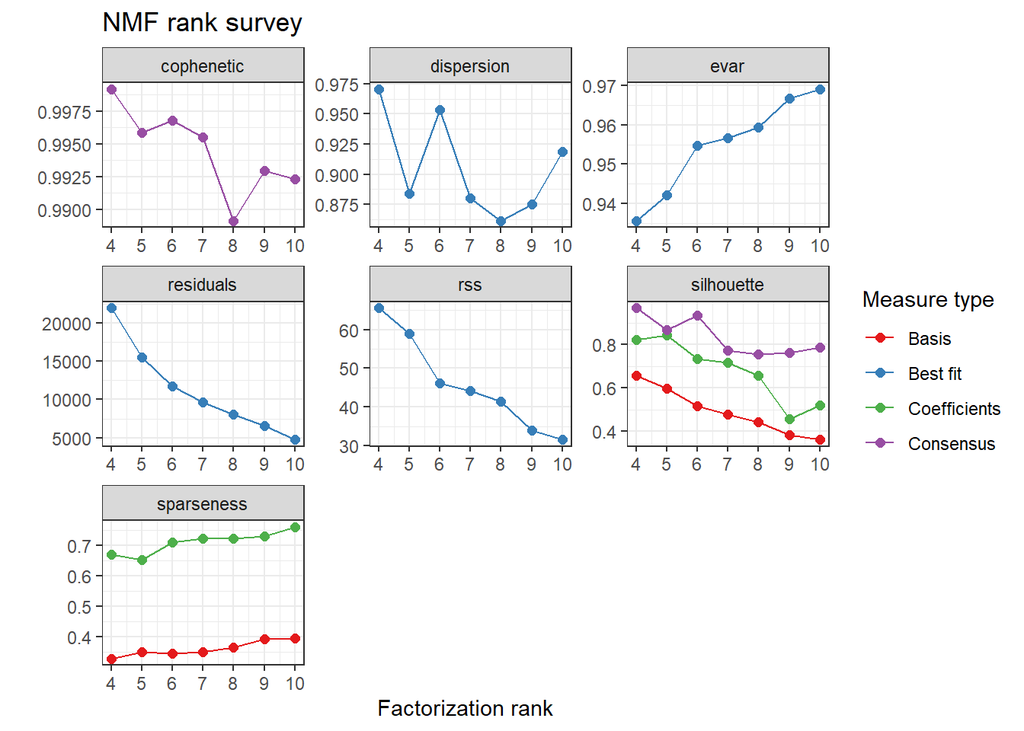

```r
# plots the NMF rank survey
plot(lsnmf_random_less_o3)
```

### Look at 5 factors:

```r
output <- lsnmf_random_less_o3$fit$`5`
W <- basis(output)
H <- coef(output)
```

#### Source Contribution plots

- Source Contribution plots

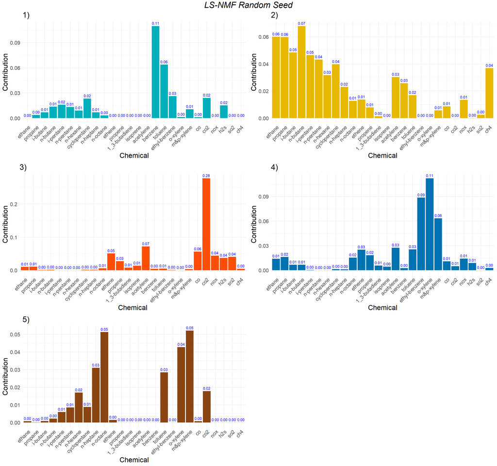

```r
# Convert H to a data frame for ggplot
H_df_5c_less_o3 <- as.data.frame(H)
# Add a column for chemicals
H_df_5c_less_o3$Component <- rownames(H_df_5c_less_o3)

# Reshape data to long format
H_long_5c_less_o3 <- pivot_longer(H_df_5c_less_o3, cols = -Component,
                                  names_to = "Chemical", values_to = "Contribution")

# Plot
nmfplt_1_lsnmf_random_less_o3_5c <- get_component_plot(H_long_5c_less_o3,
                                           '1', '1)')
nmfplt_2_lsnmf_random_less_o3_5c <- get_component_plot(H_long_5c_less_o3,
                                           '2', '2)')
nmfplt_3_lsnmf_random_less_o3_5c <- get_component_plot(H_long_5c_less_o3,
                                           '3', '3)')
nmfplt_4_lsnmf_random_less_o3_5c <- get_component_plot(H_long_5c_less_o3,
                                           '4', '4)')
nmfplt_5_lsnmf_random_less_o3_5c <- get_component_plot(H_long_5c_less_o3,
                                           '5', '5)')
```